# Week 14 Homework - TidyTuesday 4 - Learning how to do a slope chart

Author

Leah Barkai

Published

December 2, 2025

## Introduction

This document presents my Week 14 homework, using [Statistical Performance Indicators](https://github.com/rfordatascience/tidytuesday/blob/main/data/2025/2025-11-25/readme.md#statistical-performance-indicators) (SPI) dataset from TidyTuesday. The dataset measures the capacity and performance of National Statistical Systems across the globe.

In this assignment, I learned how to create a slope chart to visualize the starting (2018 score), the ending (2023 score), and amount of the score changed for each country. I decided to focus on the East Asia and Pacific region.

## Load Libraries

The following R libraries were used for this TidyTuesday assignment.

```r
library(tidyverse)     # Data manipulation and visualization
library(tidyr)         # Transforming the data into the wide format
library(forcats)       # Used for fct_reorder in the plotting section
library(here)          # Helps with file path
```

## Read in data

This data was from TidyTuesday’s [Statistical Performance Indicators](https://github.com/rfordatascience/tidytuesday/blob/main/data/2025/2025-11-25/readme.md#statistical-performance-indicators) dataset.

```r
spi_indicators <- readr::read_csv('https://raw.githubusercontent.com/rfordatascience/tidytuesday/main/data/2025/2025-11-25/spi_indicators.csv')
```

## Data Dictionary

This data dictionary is available on [TidyTuesday](https://github.com/rfordatascience/tidytuesday/blob/main/data/2025/2025-11-25/readme.md#data-dictionary) for the Statistical Performance Indicators data.

## Look at the data

This was to get an idea of what was in the data.

```
Rows: 4,340
Columns: 12
$ iso3c                     <chr> "DNK", "FIN", "POL", "SWE", "ESP", "NLD", "S…
$ country                   <chr> "Denmark", "Finland", "Poland", "Sweden", "S…
$ region                    <chr> "Europe & Central Asia", "Europe & Central A…
$ income                    <chr> "High income", "High income", "High income",…
$ year                      <dbl> 2023, 2023, 2023, 2023, 2023, 2023, 2023, 20…
$ population                <dbl> 5946952, 5584264, 36685849, 10536632, 483733…
$ overall_score             <dbl> 95.25583, 95.11542, 94.65375, 94.41000, 94.3…
$ data_use_score            <dbl> 100, 100, 100, 100, 100, 100, 100, 100, 100,…
$ data_services_score       <dbl> 98.46667, 96.43333, 97.30000, 96.00000, 91.2…
$ data_products_score       <dbl> 90.71250, 90.96875, 84.54375, 90.57500, 92.6…
$ data_sources_score        <dbl> 87.100, 88.175, 91.425, 85.475, 87.800, 83.6…
$ data_infrastructure_score <dbl> 100, 100, 100, 100, 100, 100, 100, 100, 100,…
```

## Cleaning Data

```r
slope_data <- spi_indicators %>%
  filter(
    year %in% c(2018, 2023), #Keeps only these two years
    region == "East Asia & Pacific") %>% #Keeps only EAP region
  select(country, region, year, overall_score) %>% #Keeps these columns

  pivot_wider( #Pivot data wide
    names_from = year, #Create new columns
    names_prefix = "score_", #Naming the columns by year
    values_from = overall_score) %>% #Moving the scores

 mutate(
   change = score_2023 - score_2018, #Calculate score difference
    performance_change = case_when( #Categoize change outcome
      change > 0 ~ "Improved", #Positive change
      change < 0 ~ "Declined", #Negative change
      .default = "No Change")) %>% #No change

filter(!is.na(score_2018) & !is.na(score_2023)) %>% #Remove lines with NAs

arrange(desc(change)) #Sort the data from largest gain at the top

print(head(slope_data))
```

```
# A tibble: 6 × 6
  country          region        score_2023 score_2018 change performance_change
  <chr>            <chr>              <dbl>      <dbl>  <dbl> <chr>
1 Kiribati         East Asia & …       49.0       28.1   20.9 Improved
2 Marshall Islands East Asia & …       41.0       21.3   19.7 Improved
3 Cambodia         East Asia & …       65.0       51.5   13.5 Improved
4 Lao PDR          East Asia & …       60.9       48.5   12.4 Improved
5 Vanuatu          East Asia & …       51.1       39.2   11.9 Improved
6 Singapore        East Asia & …       88.8       77.9   10.8 Improved
```

## Data Analysis

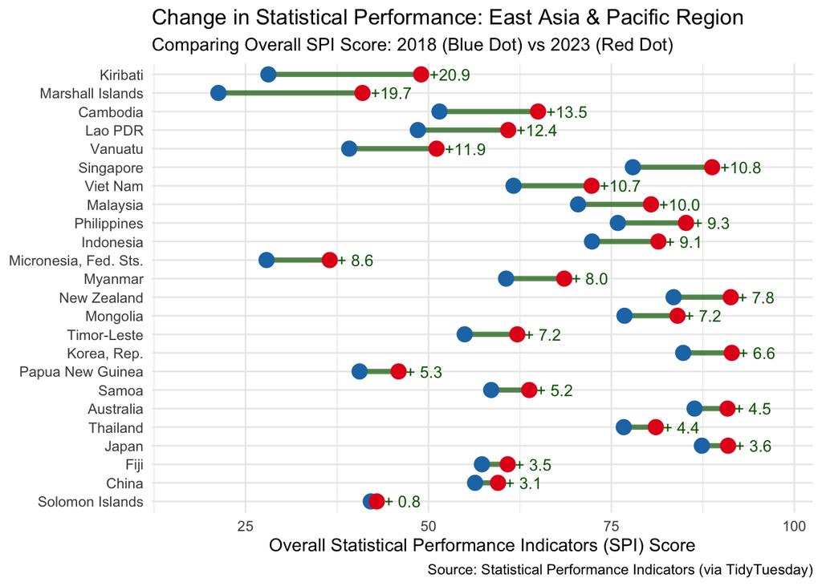

```r
max_score <- max(slope_data$score_2018, slope_data$score_2023, na.rm = TRUE) #Find max score to do axis limit

slope_chart <- ggplot(slope_data, #Make slope chart
                      aes(y = fct_reorder(country, change))) + #Order y-axis by change with most at the top
  geom_segment(
    aes(x = score_2018, xend = score_2023, #Draw line between these two points
        color = performance_change), #Color the line based on calculated category whether it was improved or declined
    linewidth = 1.5, #Thicker
    alpha = 0.7 ) + #Transparent

  geom_point(
    aes(x = score_2018), color = "#1f78b4", size = 4) + # 2018 dot info
  geom_point(
    aes(x = score_2023), color = "#e31a1c", size = 4) + #2023 dot info

  geom_text(
    aes(x = score_2023, #x-axis position
        # Format label: add '+' for gains, round to 1 decimal
        label = paste0(ifelse(change > 0, "+", ""), #Label for the change
                       format(round(change, 1), nsmall = 1)), #Number to display
        color = performance_change), # Color text to match line color
    size = 3.5, vjust = 0.5, hjust = -0.2) + #Location of label

  coord_cartesian(xlim = c(min(slope_data$score_2018) - 5, max_score + 7)) + #Extend a-axis so nothing is cut off

  scale_color_manual(
    values = c("Improved" = "darkgreen", "Declined" = "darkred", "No Change" = "gray50")
  ) + #Color of line
  labs( #Titles
    title = "Change in Statistical Performance: East Asia & Pacific Region",
    subtitle = "Comparing Overall SPI Score: 2018 (Blue Dot) vs 2023 (Red Dot)",
    caption = "Source: Statistical Performance Indicators (via TidyTuesday)",
    y = NULL,
    x = "Overall Statistical Performance Indicators (SPI) Score"
  ) +
  theme_minimal() +
  theme(legend.position = "none", legend.title = element_blank()) #No legend

# Save the plot
ggsave("../Output/spi_slope_chart_EAP.png", plot = slope_chart, width = 8, height = 10)

print(slope_chart)
```

Summary of Plot:

The Slope Chart visualizes the change in the Overall SPI Score for the East Asia & Pacific region between 2018 and 2023. The key finding is that all countries in the filtered dataset saw an increase in their overall SPI Score from 2018 to 2023. This is visually represented by the fact that all connecting lines are colored green (indicating ‘Improved’) and all lines slope upward from the blue (2018) dot to the red (2023) dot.